# Prediction of academic achievement in adolescents from teacher reports of inattention in childhood - a methodological pattern classification study

```r
~GitHub/inattention-population/code/inattention-populationsample-ann.Rmd
```

## Abstract

### Background

Inattentive behavior is associated with academic problems. The present study investigates primary school teacher reports on nine items reflecting different aspects of inattention, with an aim to reveal patterns of behavior predicting high-school academic achievement. To that end, we used different types of pattern analysis and machine learning methods.

### Methods

Inattention in a sample 2397 individuals were rated by their primary school teachers when they participated in the first wave of the Bergen Child Study (BCS) (7 - 9 years old), and their academic achievements were available from an official school register when attending high-school (16 - 19 years old). Inattention was assessed by the nine items rated at a categorical leve, and the academic achievement scores were divided into three parts including a similar number of participants.

### Results

Boys obtained higher inattention scores and lower academic scores than girls. Inattention problems related to sustained attention and distractibility turned out to have the highest predictive value of academic achievement level across all selected statistical analyses, and the full model showed that inattention explained about 10% of the variance in high school scores about 10 years later. A high odds-ration of being allocated to the lowest academic achievement category was shown by a multinominal regression analysis, while a pattern of problems related to sustained attention and distractibility was revealed by generating classification trees. By including recursive learning algorithms, the most successful classification was found between these inattention items and the highest level of achievement scores.

### Summary

The present study showed the importance of a pattern of early problems related to sustained attention and distractibility in predicting future academic results. By including different statistical classification models we showed that this pattern was fairly consistent. Furthermore, calculation of classification errors gave information about the uncertainty when predicting the outcome for individual children. Further studies should include a wider range of variables.

Organization of the data and the analysis:

Libraries being used:

- memisc - spss.system.file()
- psych - headTail(), describe()
- Hmisc - describe()
- pander - pander(), panderOptions()

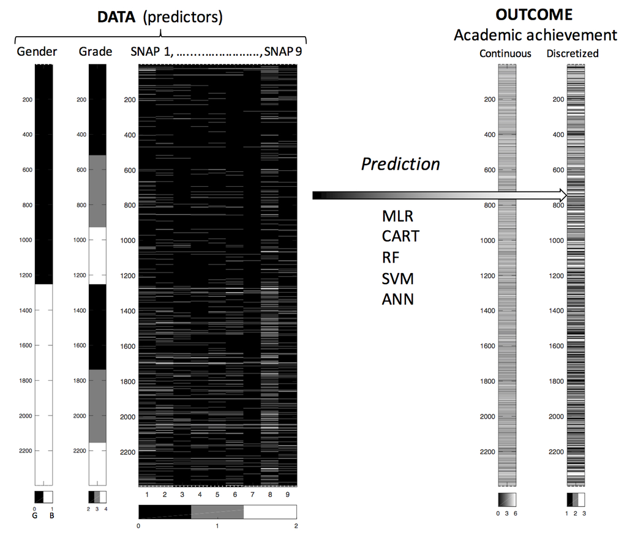

### Data preparation

Input file:

- inattention_Arvid_new.sav (from Astri, on ~/Dropbox/Arvid_inatteion/data2)
- inattention_nomiss_2397x12.csv

Output files (data):

- inattention_nomiss_2397x12_snap_is_0_1_2.csv
- inattention_nomiss_2397x12_snap_is_0_1.csv
- inattention_nomiss_2397x12_snap_is_0_1_2_outcome_is_L_M_H.csv (Low, Medium, High academic score)
- inattention_nomiss_2397x12_snap_is_0_1_2_outcome_is_0_1_2.csv (all numerical)
- inattention_nomiss_2397x12_snap_is_N_S_C_outcome_is_L_M_H.csv (Not, Somewhat, Certainly true)

```r
fn <- "../data2/inattention_Arvid_new.sav"
```

```r
# The original SPSS file as provided to AJL is
# 'inattention_Astri_94_96_new_grades_updated.sav'
# and being edited and reduced by AJL to 'inattention_Arvid_new.sav'
# Import data stored in the SPSS format
library(memisc)
fn <- "../data2/inattention_Arvid_new.sav"
data <- as.data.set(spss.system.file(fn))

# Make new data frame from the sample with the variables
# gender, grade, SNAP1, ..., SNAP9 (vars #1-11) and
# academic_achievement (var #52)
names(data)
d <- data[, c(1:11, 52)]
dim(d)
names(d)
str(d)
summary(d)
```

```r
D3 <- read.csv(file = "../data/inattention_nomiss_2397x12_snap_is_0_1_2.csv")
C <- read.csv(file = "../data/inattention_nomiss_2397x12_snap_is_0_1_2_outcome_is_L_M_H.csv")
D <- read.csv(file = "../data/inattention_nomiss_2397x12_snap_is_N_S_C_outcome_is_L_M_H.csv")
E <- read.csv(file = "../data/inattention_nomiss_2397x12_snap_is_0_1_2_outcome_is_0_1_2.csv")
str(D3)
```

```
'data.frame':   2397 obs. of  12 variables:
 $ gender: int  1 1 1 1 1 1 1 1 1 1 ...
 $ grade : int  2 2 2 2 2 2 2 2 2 2 ...
 $ snap1 : int  1 1 1 1 1 1 1 1 1 1 ...
 $ snap2 : int  1 1 1 1 1 1 1 1 1 1 ...
 $ snap3 : int  1 2 1 1 1 1 1 1 1 1 ...
 $ snap4 : int  1 1 1 1 1 1 1 1 1 1 ...
 $ snap5 : int  1 1 1 1 1 1 1 1 1 1 ...
 $ snap6 : int  1 1 1 1 1 1 1 1 1 1 ...
 $ snap7 : int  1 1 1 1 1 1 1 1 1 1 ...
 $ snap8 : int  1 1 1 1 1 1 1 1 2 1 ...
 $ snap9 : int  1 1 1 1 1 1 1 1 1 1 ...
 $ ave   : num  4.67 3.67 4.14 4.11 4.3 ...
```

```r
head(D3)
```

```
  gender grade snap1 snap2 snap3 snap4 snap5 snap6 snap7 snap8 snap9      ave
1      1     2     1     1     1     1     1     1     1     1     1 4.666667
2      1     2     1     1     2     1     1     1     1     1     1 3.666667
3      1     2     1     1     1     1     1     1     1     1     1 4.142857
4      1     2     1     1     1     1     1     1     1     1     1 4.111111
5      1     2     1     1     1     1     1     1     1     1     1 4.300000
6      1     2     1     1     1     1     1     1     1     1     1 3.888889
```

```r
str(C)
```

```
'data.frame':   2397 obs. of  12 variables:
 $ gender    : int  1 1 1 1 1 1 1 1 1 1 ...
 $ grade     : int  2 2 2 2 2 2 2 2 2 2 ...
 $ snap1     : int  1 1 1 1 1 1 1 1 1 1 ...
 $ snap2     : int  1 1 1 1 1 1 1 1 1 1 ...
 $ snap3     : int  1 2 1 1 1 1 1 1 1 1 ...
 $ snap4     : int  1 1 1 1 1 1 1 1 1 1 ...
 $ snap5     : int  1 1 1 1 1 1 1 1 1 1 ...
 $ snap6     : int  1 1 1 1 1 1 1 1 1 1 ...
 $ snap7     : int  1 1 1 1 1 1 1 1 1 1 ...
 $ snap8     : int  1 1 1 1 1 1 1 1 2 1 ...
 $ snap9     : int  1 1 1 1 1 1 1 1 1 1 ...
 $ averBinned: Factor w/ 3 levels "H","L","M": 1 2 3 3 3 3 2 3 1 3 ...
```

```r
head(C)
```

```
  gender grade snap1 snap2 snap3 snap4 snap5 snap6 snap7 snap8 snap9 averBinned
1      1     2     1     1     1     1     1     1     1     1     1          H
2      1     2     1     1     2     1     1     1     1     1     1          L
3      1     2     1     1     1     1     1     1     1     1     1          M
4      1     2     1     1     1     1     1     1     1     1     1          M
5      1     2     1     1     1     1     1     1     1     1     1          M
6      1     2     1     1     1     1     1     1     1     1     1          M
```

```r
str(D)
```

```
'data.frame':   2397 obs. of  12 variables:
 $ gender    : Factor w/ 2 levels "B","G": 1 1 1 1 1 1 1 1 1 1 ...
 $ grade     : Factor w/ 3 levels "2nd","3rd","4th": 1 1 1 1 1 1 1 1 1 1 ...
 $ snap1     : Factor w/ 3 levels "C","N","S": 3 3 3 3 3 3 3 3 3 3 ...
 $ snap2     : Factor w/ 3 levels "C","N","S": 3 3 3 3 3 3 3 3 3 3 ...
 $ snap3     : Factor w/ 3 levels "C","N","S": 3 1 3 3 3 3 3 3 3 3 ...
 $ snap4     : Factor w/ 3 levels "C","N","S": 3 3 3 3 3 3 3 3 3 3 ...
 $ snap5     : Factor w/ 3 levels "C","N","S": 3 3 3 3 3 3 3 3 3 3 ...
 $ snap6     : Factor w/ 3 levels "C","N","S": 3 3 3 3 3 3 3 3 3 3 ...
 $ snap7     : Factor w/ 3 levels "C","N","S": 3 3 3 3 3 3 3 3 3 3 ...
 $ snap8     : Factor w/ 3 levels "C","N","S": 3 3 3 3 3 3 3 3 1 3 ...
 $ snap9     : Factor w/ 3 levels "C","N","S": 3 3 3 3 3 3 3 3 3 3 ...
 $ averBinned: Factor w/ 3 levels "H","L","M": 1 2 3 3 3 3 2 3 1 3 ...
```

```r
head(D)
```

```
  gender grade snap1 snap2 snap3 snap4 snap5 snap6 snap7 snap8 snap9 averBinned
1      B   2nd     S     S     S     S     S     S     S     S     S          H
2      B   2nd     S     S     C     S     S     S     S     S     S          L
3      B   2nd     S     S     S     S     S     S     S     S     S          M
4      B   2nd     S     S     S     S     S     S     S     S     S          M
5      B   2nd     S     S     S     S     S     S     S     S     S          M
6      B   2nd     S     S     S     S     S     S     S     S     S          M
```

```r
str(E)
```

```
'data.frame':   2397 obs. of  12 variables:
 $ gender    : int  1 1 1 1 1 1 1 1 1 1 ...
 $ grade     : int  2 2 2 2 2 2 2 2 2 2 ...
 $ snap1     : int  1 1 1 1 1 1 1 1 1 1 ...
 $ snap2     : int  1 1 1 1 1 1 1 1 1 1 ...
 $ snap3     : int  1 2 1 1 1 1 1 1 1 1 ...
 $ snap4     : int  1 1 1 1 1 1 1 1 1 1 ...
 $ snap5     : int  1 1 1 1 1 1 1 1 1 1 ...
 $ snap6     : int  1 1 1 1 1 1 1 1 1 1 ...
 $ snap7     : int  1 1 1 1 1 1 1 1 1 1 ...
 $ snap8     : int  1 1 1 1 1 1 1 1 2 1 ...
 $ snap9     : int  1 1 1 1 1 1 1 1 1 1 ...
 $ averBinned: int  2 0 1 1 1 1 0 1 2 1 ...
```

```r
head(E)
```

```
  gender grade snap1 snap2 snap3 snap4 snap5 snap6 snap7 snap8 snap9 averBinned
1      1     2     1     1     1     1     1     1     1     1     1          2
2      1     2     1     1     2     1     1     1     1     1     1          0
3      1     2     1     1     1     1     1     1     1     1     1          1
4      1     2     1     1     1     1     1     1     1     1     1          1
5      1     2     1     1     1     1     1     1     1     1     1          1
6      1     2     1     1     1     1     1     1     1     1     1          1
```

### Using the NNET package

The caret package (short for classification and regression training) contains functions to streamline the model training process for complex regression and classification problems. The package utilizes a number of R packages but tries not to load them all at package start-up. The package “suggests” field includes 27 packages. caret loads packages as needed and assumes that they are installed.

```r
E$averBinnedF = as.factor(E$averBinned)  # To perform clasification and not regression
E <- subset(E, select = -c(averBinned))
```

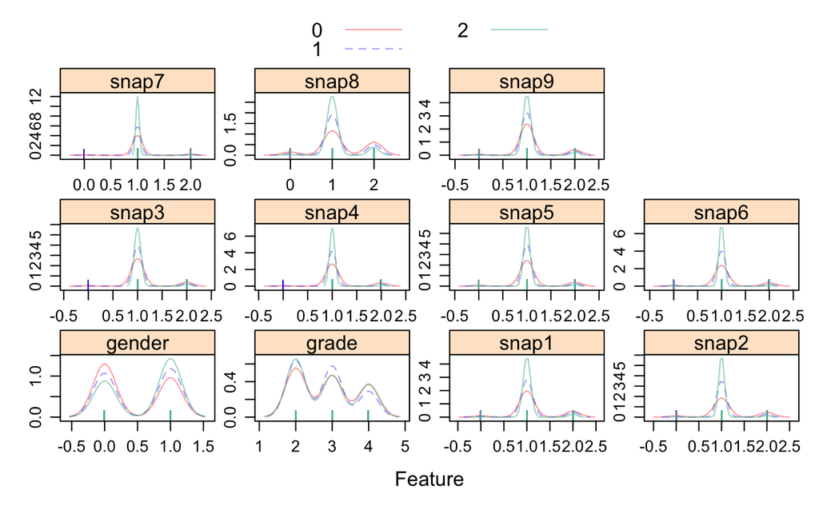

```r
library(caret)
# Feature density plots
library(AppliedPredictiveModeling)
transparentTheme(trans = 0.4)
# plt <- featurePlot(x = E[, 1:11],
featurePlot(x = E[, 1:11],
            y = E$averBinnedF,
            plot = "density",
            scales = list(x = list(relation="free"),
                          y = list(relation="free")),
            pch = "|",
            adjust = 1.5,
            layout = c(4,3),
            ## Add a key at the top
            auto.key = list(columns = 2))
```

```r
# plot(plt)
```

```r
# Functions and Datasets from J. Fox and S. Weisberg, An R Companion to Applied Regression,
# Second Edition, Sage, 2011.
library(car)
# Keep 75 (70) % of the observations for training the classifier,
# and 25 (30) % of the sample for performance evaluation (e.g. confusion matrix)
set.seed(998)
trainIndex <- createDataPartition(E$averBinnedF, p=.75, list=F)
# trainIndex <- createDataPartition(data$class, p=.70, list=F)
E.train <- E[trainIndex, ]
E.test <- E[-trainIndex, ]
# Check the random sample used for training
head(trainIndex)
```

```
     Resample1
[1,]         2
[2,]         3
[3,]         4
[4,]         5
[5,]         6
[6,]         7
```

Train the RF or ANN model on the training set (caret package) check: to http://cran.r-project.org/web/packages/nnet/nnet.pdf, and http://topepo.github.io/caret/training.html The function train() sets up a grid of tuning parameters for a number of classification and regression routines, fits each model and calculates a resampling based performance measure. method - a string specifying which classification or regression model to use see http://topepo.github.io/caret/bytag.html and https://www.byclb.com/TR/Tutorials/neural_networks/ch10_1.htm !!

```r
# The function trainControl can be used to specifiy the type of resampling in the training set
fitControl <- trainControl(   ## 10-fold CV [cross validation]
  method = "repeatedcv",
  number = 10,
  ## repeated ten times
  repeats = 10)
# Preprocessing (normalization) of training data
# Check: https://github.com/topepo/caret/issues/160
pp.E.train <- preProcess(E.train, method = c("center", "scale"))
pp.E.train <- predict.preProcess(pp.E.train, E.train)
# Preprocessing (normalization) of test data
pp.E.test <- preProcess(E.test, method = c("center", "scale"))
pp.E.test <- predict.preProcess(pp.E.test, E.test)
head(pp.E.train)
```

```
     gender     grade      snap1      snap2      snap3      snap4      snap5      snap6
2 0.9398289 -1.047413 -0.2742621 -0.2270259  3.3681232 -0.2405842 -0.2093698 -0.1934578
3 0.9398289 -1.047413 -0.2742621 -0.2270259 -0.2450274 -0.2405842 -0.2093698 -0.1934578
4 0.9398289 -1.047413 -0.2742621 -0.2270259 -0.2450274 -0.2405842 -0.2093698 -0.1934578
5 0.9398289 -1.047413 -0.2742621 -0.2270259 -0.2450274 -0.2405842 -0.2093698 -0.1934578
6 0.9398289 -1.047413 -0.2742621 -0.2270259 -0.2450274 -0.2405842 -0.2093698 -0.1934578
7 0.9398289 -1.047413 -0.2742621 -0.2270259 -0.2450274 -0.2405842 -0.2093698 -0.1934578
       snap7      snap8      snap9 averBinnedF
2 -0.1287429 -0.3676731 -0.2598538           0
3 -0.1287429 -0.3676731 -0.2598538           1
4 -0.1287429 -0.3676731 -0.2598538           1
5 -0.1287429 -0.3676731 -0.2598538           1
6 -0.1287429 -0.3676731 -0.2598538           1
7 -0.1287429 -0.3676731 -0.2598538           0
```

```r
head(E.train)
```

```
  gender grade snap1 snap2 snap3 snap4 snap5 snap6 snap7 snap8 snap9 averBinnedF
2      1     2     1     1     2     1     1     1     1     1     1           0
3      1     2     1     1     1     1     1     1     1     1     1           1
4      1     2     1     1     1     1     1     1     1     1     1           1
5      1     2     1     1     1     1     1     1     1     1     1           1
6      1     2     1     1     1     1     1     1     1     1     1           1
7      1     2     1     1     1     1     1     1     1     1     1           0
```

```r
head(pp.E.test)
```

```
      gender      grade      snap1      snap2      snap3     snap4      snap5      snap6
1  0.9925024 -0.9908417 -0.2480727 -0.2196087 -0.2628994 -0.201808 -0.2141878 -0.2299626
13 0.9925024 -0.9908417 -0.2480727 -0.2196087 -0.2628994 -0.201808 -0.2141878 -0.2299626
15 0.9925024 -0.9908417 -0.2480727 -0.2196087 -0.2628994 -0.201808 -0.2141878 -0.2299626
19 0.9925024 -0.9908417 -0.2480727 -0.2196087 -0.2628994 -0.201808 -0.2141878 -0.2299626
23 0.9925024 -0.9908417 -0.2480727 -0.2196087 -0.2628994 -0.201808 -0.2141878 -0.2299626
24 0.9925024 -0.9908417 -0.2480727 -0.2196087 -0.2628994 -0.201808 -0.2141878 -0.2299626
        snap7      snap8      snap9 averBinnedF
1  -0.1656666 -0.3760264 -0.2852515           2
13 -0.1656666  1.8071174 -0.2852515           1
15 -0.1656666 -0.3760264 -0.2852515           2
19 -0.1656666 -0.3760264 -0.2852515           0
23 -0.1656666 -0.3760264 -0.2852515           0
24 -0.1656666 -0.3760264 -0.2852515           0
```

```r
head(E.test)
```

```
   gender grade snap1 snap2 snap3 snap4 snap5 snap6 snap7 snap8 snap9 averBinnedF
1       1     2     1     1     1     1     1     1     1     1     1           2
13      1     2     1     1     1     1     1     1     1     2     1           1
15      1     2     1     1     1     1     1     1     1     1     1           2
19      1     2     1     1     1     1     1     1     1     1     1           0
23      1     2     1     1     1     1     1     1     1     1     1           0
24      1     2     1     1     1     1     1     1     1     1     1           0
```

```r
# Neural Network classifier  cf. help(nnet)
# method = 'nnet'
# Type: Classification, Regression
# Tuning Parameters: size (#Hidden Units), decay (Weight Decay)
# For these caret models, train can automatically create a grid of tuning parameters.
# By default, if p is the number of tuning parameters, the grid size is 3^p.
# For nnet we explore
my.nnet.grid <- expand.grid(.decay = c(0.05, 0.10, 0.15, 0.20, 0.25), .size = c(3, 5, 7, 9))
E.nnet.fit <- train(averBinnedF ~. , data = E.train,
                       method = "nnet",
                       maxit = 1000,
                       trControl = fitControl,
                       tuneGrid = my.nnet.grid,
                       trace = FALSE)
print(E.nnet.fit$finalModel$problemType)
```

```
[1] "Classification"
```

```r
print(E.nnet.fit$finalModel$n)
```

```
[1] 11  5  3
```

```r
print(E.nnet.fit$finalModel$call)
```

```
nnet.formula(formula = .outcome ~ ., data = dat, size = param$size,
    decay = param$decay, maxit = 1000, trace = FALSE)
```

```r
print(E.nnet.fit$finalModel)
```

```
a 11-5-3 network with 78 weights
inputs: gender grade snap1 snap2 snap3 snap4 snap5 snap6 snap7 snap8 snap9
output(s): .outcome
options were - softmax modelling  decay=0.2
```

```r
print(E.nnet.fit)
```

```
Neural Network

1799 samples
  11 predictor
   3 classes: '0', '1', '2'

No pre-processing
Resampling: Cross-Validated (10 fold, repeated 10 times)
Summary of sample sizes: 1620, 1618, 1618, 1620, 1620, 1620, ...
Resampling results across tuning parameters:

  decay  size  Accuracy   Kappa
  0.05   3     0.4289399  0.1433202
  0.05   5     0.4298297  0.1445570
  0.05   7     0.4252305  0.1374092
  0.05   9     0.4204937  0.1300370
  0.10   3     0.4259469  0.1387688
  0.10   5     0.4266676  0.1396363
  0.10   7     0.4283321  0.1421259
  0.10   9     0.4262648  0.1388593
  0.15   3     0.4277741  0.1414561
  0.15   5     0.4313924  0.1467914
  0.15   7     0.4322788  0.1481298
  0.15   9     0.4264994  0.1392781
  0.20   3     0.4298782  0.1444615
  0.20   5     0.4352289  0.1525810
  0.20   7     0.4337304  0.1503296
  0.20   9     0.4296671  0.1441827
  0.25   3     0.4306581  0.1456466
  0.25   5     0.4330433  0.1492367
  0.25   7     0.4324514  0.1483336
  0.25   9     0.4292747  0.1436354

Accuracy was used to select the optimal model using  the largest value.
The final values used for the model were size = 5 and decay = 0.2.
```

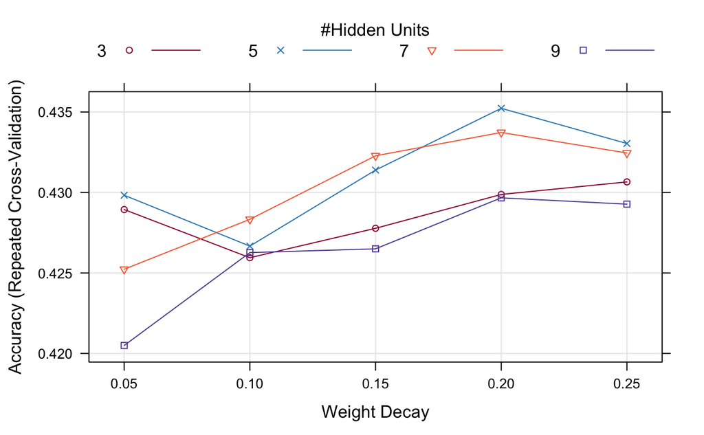

```r
trellis.par.set(caretTheme())
plot(E.nnet.fit)
```

```r
# Call predict on the fitted object using the test data set
E.test.nnet.predict <- predict(E.nnet.fit, newdata = E.test, na.action = na.omit, verbose = TRUE)
print(summary(as.data.frame(E.test.nnet.predict)))
```

```
 E.test.nnet.predict
 0:120
 1:136
 2:342
```

```r
print(summary(as.data.frame(E.test$averBinnedF)))
```

```
 E.test$averBinnedF
 0:194
 1:204
 2:200
```

```r
# Assess confusion matrix
cm.nnet.fit.E.test <- confusionMatrix(E.test.nnet.predict, E.test$averBinnedF)
print(cm.nnet.fit.E.test)
```

```
Confusion Matrix and Statistics

          Reference
Prediction   0   1   2
         0  60  40  20
         1  49  52  35
         2  85 112 145

Overall Statistics

               Accuracy : 0.4298
                 95% CI : (0.3897, 0.4705)
    No Information Rate : 0.3411
    P-Value [Acc > NIR] : 4.199e-06

                  Kappa : 0.1438
 Mcnemar's Test P-Value : < 2.2e-16

Statistics by Class:

                     Class: 0 Class: 1 Class: 2
Sensitivity            0.3093  0.25490   0.7250
Specificity            0.8515  0.78680   0.5050
Pos Pred Value         0.5000  0.38235   0.4240
Neg Pred Value         0.7197  0.67100   0.7852
Prevalence             0.3244  0.34114   0.3344
Detection Rate         0.1003  0.08696   0.2425
Detection Prevalence   0.2007  0.22742   0.5719
Balanced Accuracy      0.5804  0.52085   0.6150
```

```r
library(plyr)
#mapvalues(E$averBinnedF, from = c("0", "1", "2"), to = c("L", "M", "H"))
#revalue(E$averBinnedF, c("0"="L", "1"="M", "2"="H"))
levels(E$averBinnedF)[levels(E$averBinnedF)=="0"] <- "L"
levels(E$averBinnedF)[levels(E$averBinnedF)=="1"] <- "M"
levels(E$averBinnedF)[levels(E$averBinnedF)=="2"] <- "H"

set.seed(998)
trainIndex <- createDataPartition(E$averBinnedF, p=.75, list=F)
# trainIndex <- createDataPartition(data$class, p=.70, list=F)
E.train <- E[trainIndex, ]
E.test <- E[-trainIndex, ]
```

```r
fitControl <- trainControl(   ## 10-fold CV [cross validation]
  method = "repeatedcv",
  number = 10,
  ## repeated ten times
  repeats = 10,
  classProbs = TRUE)
```

```r
svmFit <- train(averBinnedF ~ . , data = E.train,
                 method = "svmRadial",
                 trControl = fitControl,
                 tuneLength = 8,
                 metric = "ROC")
svmFit
```

[output not shown]

```r
# Call predict on the fitted object using the test data set
E.test.svm.predict <- predict(svmFit, newdata = E.test, na.action = na.omit, verbose = TRUE)
print(summary(as.data.frame(E.test.svm.predict)))
print(summary(as.data.frame(E.test$averBinnedF)))

# Assess confusion matrix
cm.svm.fit.E.test <- confusionMatrix(E.test.svm.predict, E.test$averBinnedF)
print(cm.svm.fit.E.test)
```

[output not shown]